# Week-10-DataDive-GLMs

Raghuveer Venkatesh

2024-11-04

# Introduction

In this project, we explore preferred foot (right vs. left) as a binary variable to see how it relates to player skills and physical attributes. Using logistic regression, we’ll interpret the effects of key attributes, build a confidence interval for one coefficient, and discuss the insights gained along with potential follow-up questions.

## Why Preferred foot ?

This column can be converted into binary value easily Left Foot = 0, Right Foot = 1. Preferred foot can significantly influence a player’s performance in certain positions or play styles, which might correlate with overall ratings, specific skill metrics (like crossing or finishing), or market value.

# Logistic Regression Model for Preferred foot

```r
#Encoding the values as 0 and 1.

player_data <- player_data |>
  mutate(preferred_foot_binary = ifelse(preferred_foot == "Right", 1, 0))

# Select the explanatory variables
explanatory_vars <- c("agility", "ball_control", "crossing", "dribbling")


model <- glm(preferred_foot_binary ~ agility + ball_control + crossing + dribbling,
             data = player_data, family = binomial(link = "logit"))


summary(model)
```

```
##
## Call:
## glm(formula = preferred_foot_binary ~ agility + ball_control +
##     crossing + dribbling, family = binomial(link = "logit"),
##     data = player_data)
##
## Coefficients:
##               Estimate Std. Error z value Pr(>|z|)
## (Intercept)   1.997097   0.099173  20.137   <2e-16 ***
## agility       0.005034   0.002010   2.505   0.0122 *
## ball_control  0.030941   0.003536   8.750   <2e-16 ***
## crossing     -0.054515   0.002186 -24.938   <2e-16 ***
## dribbling    -0.002077   0.003434  -0.605   0.5452
## ---
## Signif. codes:  0 '***' 0.001 '**' 0.01 '*' 0.05 '.' 0.1 ' ' 1
##
## (Dispersion parameter for binomial family taken to be 1)
##
##     Null deviance: 19469  on 17953  degrees of freedom
## Residual deviance: 18417  on 17949  degrees of freedom
## AIC: 18427
##
## Number of Fisher Scoring iterations: 4
```

```r
exp(coef(model))
```

```
##  (Intercept)      agility ball_control     crossing    dribbling
##    7.3676334    1.0050472    1.0314251    0.9469442    0.9979247
```

## Explaining the co-efficients

Intercept: 1.997097 **Odds Ratio**: exp(1.9971) ≈ 7.37 This suggests that at baseline, odds are a player is 7.37 times more likely to be right-footed than left-footed.

Agility **Odds Ratio**: exp(0.0050) ≈ 1.005 Each point increase in agility raises the odds of being right footed by 0.5%

Ball Control: 0.0309 **Odds Ratio**: exp(0.0309) ≈ 1.031 For each additional point in ball control, the odds of being right-footed increase by approximately 3.1%, indicating that ball control is positively associated with right-foot preference.

Crossing: -0.0545 **Odds Ratio**: exp(-0.0545) ≈ 0.947 Each additional point in crossing skill slightly decreases the odds of being right-footed by about 5.3%, suggesting that players with higher crossing ability may be more likely to prefer their left foot.

Dribbling: -0.0021 **Odds Ratio**: exp(-0.0021) ≈ 0.998 With an odds ratio near 1, each point increase in dribbling has no meaningful impact on the odds of being right-footed, indicating that dribbling skill does not significantly influence foot preference.

## Plotting the model using Agility

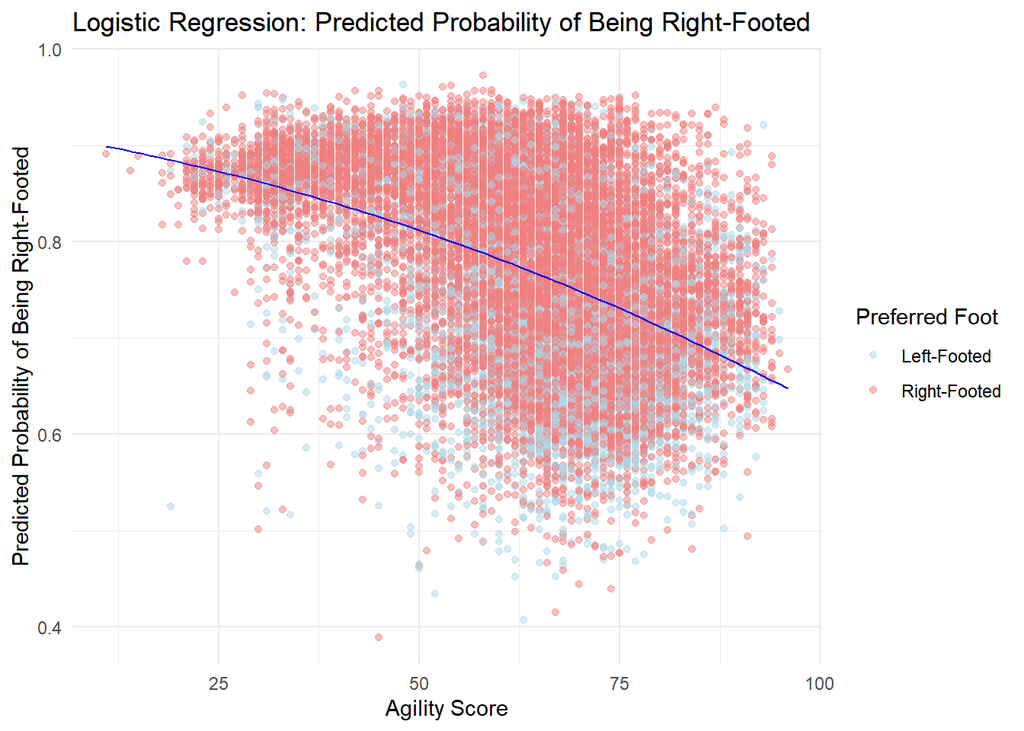

```r
player_data$predicted_prob <- predict(model, type = "response")

# Create a plot
ggplot(player_data, aes(x = agility, y = predicted_prob)) +
  geom_point(aes(color = preferred_foot), alpha = 0.5) +  # Original data points
  geom_line(stat = "smooth", method = "glm", method.args = list(family = "binomial"), color = "blue") +  # Logistic regression curve
  labs(title = "Logistic Regression: Predicted Probability of Being Right-Footed",
       x = "Agility Score",
       y = "Predicted Probability of Being Right-Footed") +
  scale_color_manual(values = c("lightblue", "lightcoral"),
                     name = "Preferred Foot",
                     labels = c("Left-Footed", "Right-Footed")) +
  theme_minimal()
```

# Confidence Interval and Standard error for Agility

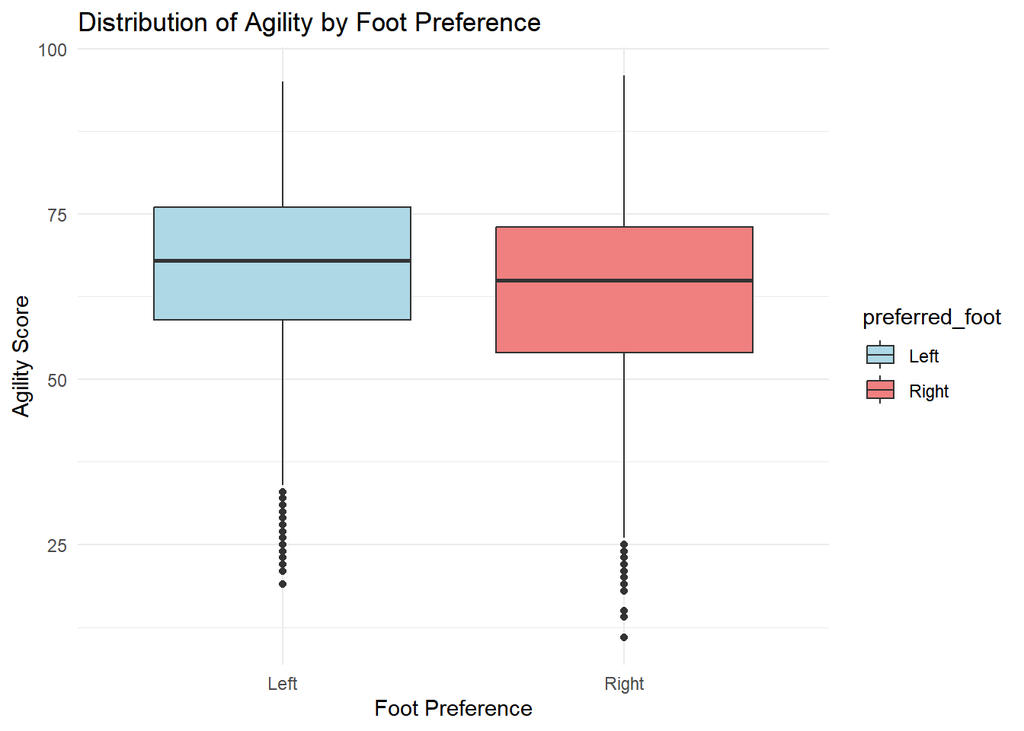

```r
ggplot(player_data, aes(x = preferred_foot, y = agility, fill = preferred_foot)) +
  geom_boxplot() +
  labs(title = "Distribution of Agility by Foot Preference",
       x = "Foot Preference",
       y = "Agility Score") +
  theme_minimal() +
  scale_fill_manual(values = c("lightblue", "lightcoral"))
```

```r
coef_agility <- coef(model)["agility"]
se_agility <- summary(model)$coefficients["agility", "Std. Error"]


# Calculate the 95% Confidence Interval for agility coefficient
ci_lower <- coef_agility - 1.96 * se_agility
ci_upper <- coef_agility + 1.96 * se_agility

# Exponentiation of the CI to interpret it as an odds ratio range
ci_odds_ratio <- exp(c(ci_lower, ci_upper))

# Print results
cat("Odds Ratio for Agility:", exp(coef_agility), "\n")
```

```
## Odds Ratio for Agility: 1.005047
```

```r
cat("95% Confidence Interval for Odds Ratio of Agility:", ci_odds_ratio, "\n")
```

```
## 95% Confidence Interval for Odds Ratio of Agility: 1.001096 1.009014
```

### Interpretation

For each one-point increase in agility, the odds of a player being right-footed increase by approximately 0.5%.

CI ranges from 1.0011 to 1.0090 meaning range of values that we are 95% confident contains the true odds ratio of agility in the population from which the sample was drawn.

## Further questions

How does these findings vary across different nationalities ?.

Does it have the same impact on players with high rating as well as players with low rating ?